# Project: Systemic And Banking Crisis.

### **Title**: The effect of variables on systemic and banking crisis.

## Table of Contents:

- Introduction
- Analysis The Target.
- conclusions of Analysis

## Introduction

> **Systemic And Banking Crisis** This data containsthe the Systemic and the banking crises of 70 countries, from 1800 AD to 2016 AD, with a total of 8642 records and 17 variables.

### **Variable | Description***:

- **1-Case**: ID Number for Country.
- **2-Cc3**: ID String for Country.
- **3-Country**: Name Country.
- **4-Yea**: The date from 1800 to 2016.
- **5-Banking_Crisis**: Banking problems can often be traced to a decrease the value of banks' assets:
  > - A) due to a collapse in real estate prices or When the bank asset values decrease substantially.
  > - B) if a government stops paying its obligations, this can trigger a sharp decline in value of bonds.
- **6-Systemic_Crisis**: When many banks in a country are in serious solvency or liquidity problems at the same time—either:
  > - A) because there are all hits by the same outside shock.
  > - B) or because failure in one bank or a group of banks spreads to other banks in the system.
- **7-Gold_Standard**: The Country have crisis in Gold Standard.
- **8-Exch_Usd**: Exch local currency in USD, Except exch USD currency in GBP.
- **9-Domestic_Debt_In_Default**: The Country have domestic debt in default.
- **10-Sovereign_External_Debt_1**: Default and Restructurings, 1800-2012--Does not include defaults on WWI debt to United States and United Kingdom and post-1975 defaults on Official External Creditors.
- **11-Sovereign_External_Debt_2**: Default and Restructurings, 1800-2012--Does not include defaults on WWI debt to United States and United Kingdom but includes post-1975 defaults on Official External Creditors.
- **12-Gdp_Weighted_Default**: GDP Weighted Default for country.
- **13-Inflation**: Annual percentages of average consumer prices.
- **14-Independence**: Independence for country.
- **15-Currency_Crises**: The Country have crisis in Currency.
- **16-Inflation_Crises**: The Country have crisis in Inflation.
- **17-Level_Country**: The description of the country whether it's Developing or Developed.

## **Research Questiones**:-

Research Question 1 : Does 'Gold_Standard' affect systemic or banking crisis?

Research Question 2 : Does 'Domestic_Debt_In_Default' affect systemic or banking crisis?

Research Question 3 : Does 'Sovereign_External_Debt_1' affect systemic or banking crisis?

Research Question 4 : Does 'Sovereign_External_Debt_2' affect systemic or banking crisis?

Research Question 5 : Does 'Independence' affect systemic or banking crisis?

Research Question 6 : Does 'Currency_Crises' affect systemic or banking crisis?

Research Question 7 : Does 'Inflation_Crises' affect systemic or banking crisis?

Research Question 8 : Does 'Level_Country' affect systemic or banking crisis?

Research Question 9 : Does 'Exch_Usd' affect systemic or banking crisis?

Research Question 10 : Does 'Gdp_Weighted_Default' affect systemic or banking crisis?

Research Question 11 : Does 'Inflation' affect systemic or banking crisis?

Research Question 12 : Is there a relationship between Inflation, Inflation_crises, Currency_Crises?

Research Question 13 : Is there a relationship between Domestic_Debt_In_Default , Sovereign_External_Debt_1, Sovereign_External_Debt_2, GDP_Weighted_Default?

```python
df.info()
```

```
<class 'pandas.core.frame.DataFrame'>
RangeIndex: 8642 entries, 0 to 8641
Data columns (total 17 columns):
 #   Column                     Non-Null Count  Dtype
---  ------                     --------------  -----
 0   Case                       8642 non-null   int64
 1   Cc3                        8642 non-null   object
 2   Country                    8642 non-null   object
 3   Year                       8642 non-null   int64
 4   Banking_Crisis             8642 non-null   int64
 5   Systemic_Crisis            8642 non-null   int64
 6   Gold_Standard              8642 non-null   int64
 7   Exch_Usd                   8642 non-null   float64
 8   Domestic_Debt_In_Default   8642 non-null   int64
 9   Sovereign_External_Debt_1  8642 non-null   int64
 10  Sovereign_External_Debt_2  8642 non-null   int64
 11  Gdp_Weighted_Default       8642 non-null   float64
 12  Inflation                  8642 non-null   float64
 13  Independence               8642 non-null   int64
 14  Currency_Crises            8642 non-null   int64
 15  Inflation_Crises           8642 non-null   int64
 16  Level_Country              8642 non-null   object
dtypes: float64(3), int64(11), object(3)
memory usage: 1.1+ MB
```

```python
df["Level_Country"].describe()
```

```
count                   8642
unique                     2
top       Developing regions
freq                    4556
Name: Level_Country, dtype: object
```

## Analysis The Target.

> Here we will Analysis The varible of target(Systemic And Banking Crisis), calculate statistics and create visualizations in order to address the research questions I asked in the Introduction section.

## Systemic_Crisis

```
0    8105
1     537
Name: Systemic_Crisis, dtype: int64
```

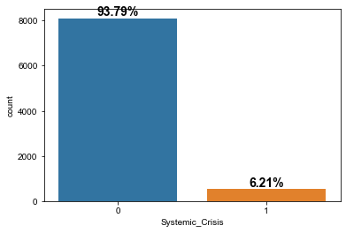

```python
CountPercent(df,"Systemic_Crisis")
df["Systemic_Crisis"].value_counts()
```

## Banking_Crisis

```
0    7854
1     788
Name: Banking_Crisis, dtype: int64
```

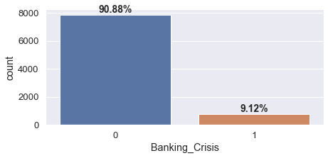

```python
CountPercent(df,"Banking_Crisis")
df["Banking_Crisis"].value_counts()
```

```
>- not` Systemic_Crisis And with `not` Banking_Crisis >>>`N`= 7805
>- `not` Systemic_Crisis And with Banking_Crisis >>>`B`= 300
>- Systemic_Crisis And with `not` Banking_Crisis >>>`S`= 49
>- Systemic_Crisis And with Banking_Crisis >>>`SB`= 488
```

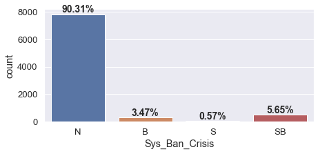

```python
dsb["Sys_Ban_Crisis"]=dsb["Sys_Ban_Crisis"].astype(cat_dtype)

CountPercent(dsb,"Sys_Ban_Crisis",[8,4])
n,sb,b,s=dsb["Sys_Ban_Crisis"].value_counts()

print(f""">- not` Systemic_Crisis And with `not` Banking_Crisis >>>`N`= {n}
>- `not` Systemic_Crisis And with Banking_Crisis >>>`B`= {b}
>- Systemic_Crisis And with `not` Banking_Crisis >>>`S`= {s}
>- Systemic_Crisis And with Banking_Crisis >>>`SB`= {sb}""")
```

### It is clear from the above:

> - the occurrence of `Banking Crisis` Cause in a `Systemic Crisis`, at a rate of `62%`.
> - In contrast, that the occurrence of `Systemic Crisis` It was because a `Banking Crisis`, at a rate of `91%`.
> - The occurrence rate of `Banking Crisis` are higher than `Systemic Crisis` by `47%`.

## Gold_Standard

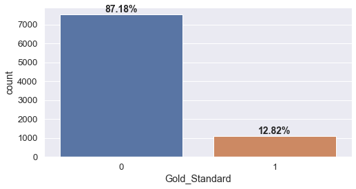

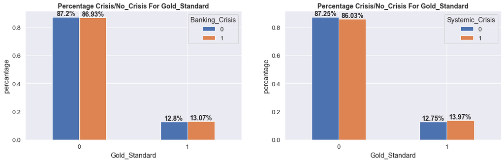

```python
CountPercent(df,"Gold_Standard")
plt.subplots(figsize=[18,5])
myBarPercent(df,"Gold_Standard","Banking_Crisis", 1,2,1);
myBarPercent(df,"Gold_Standard","Systemic_Crisis", 1,2,2);
```

## Domestic_Debt_In_Default

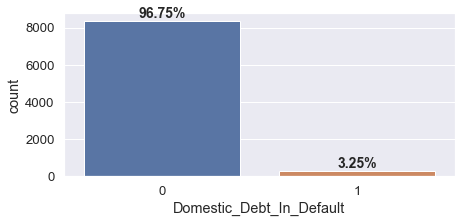

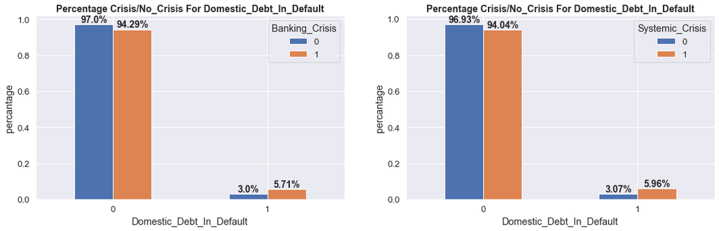

```python
CountPercent(df,"Domestic_Debt_In_Default")

plt.subplots(figsize=[18,5])
myBarPercent(df,"Domestic_Debt_In_Default","Banking_Crisis", 1,2,1);
myBarPercent(df,"Domestic_Debt_In_Default","Systemic_Crisis",1,2,2);
```

#### `Domestic Debt In Default` affect on `systemic crisis` and `banking crisis` by positive.

## Sovereign_External_Debt_1

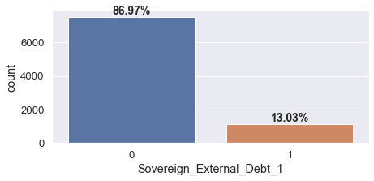

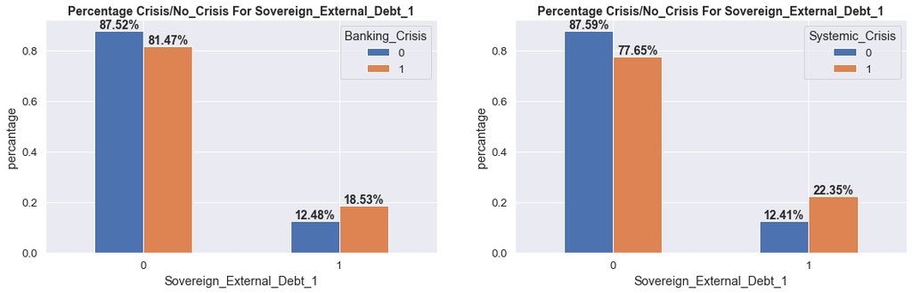

```python
CountPercent(df,"Sovereign_External_Debt_1")
plt.subplots(figsize=[18,5])
myBarPercent(df,"Sovereign_External_Debt_1","Banking_Crisis", 1,2,1)
myBarPercent(df,"Sovereign_External_Debt_1","Systemic_Crisis", 1,2,2)
```

#### `Sovereign External Debt 1` affect on `systemic crisis` and `banking crisis` by positive.

## Sovereign_External_Debt_2

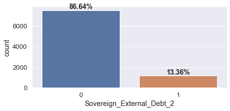

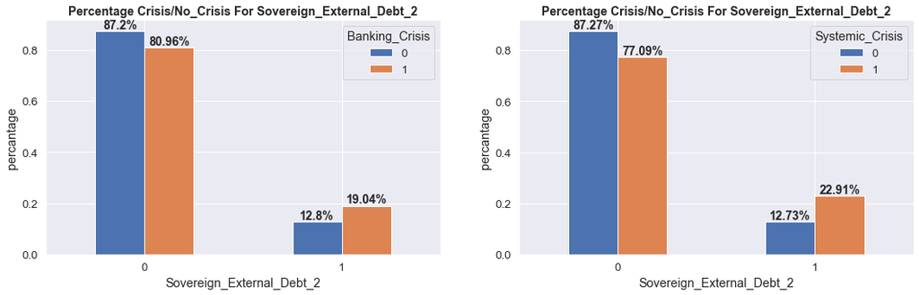

```python
CountPercent(df,"Sovereign_External_Debt_2")
plt.subplots(figsize=[18,5])
myBarPercent(df,"Sovereign_External_Debt_2","Banking_Crisis", 1,2,1)
myBarPercent(df,"Sovereign_External_Debt_2","Systemic_Crisis", 1,2,2)
```

#### `Sovereign External Debt 2` affect on `systemic crisis` and `banking crisis` by positive.

## Independence

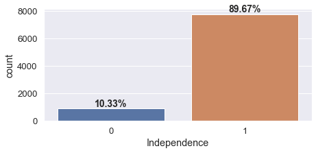

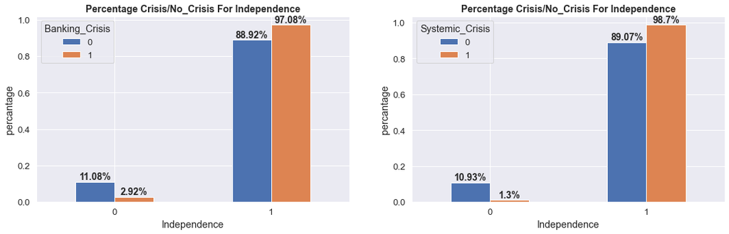

```python
CountPercent(df,"Independence")
plt.subplots(figsize=[18,5])
myBarPercent(df,"Independence","Banking_Crisis", 1,2,1)
myBarPercent(df,"Independence","Systemic_Crisis", 1,2,2)
```

#### `Independence` affect on `systemic crisis` and `banking crisis` by positive.

## Currency_Crises

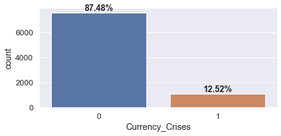

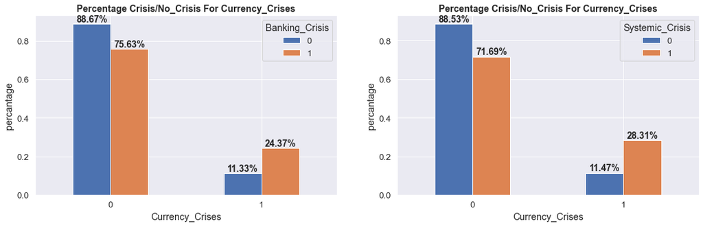

```python
CountPercent(df,"Currency_Crises")
plt.subplots(figsize=[18,5])
myBarPercent(df,"Currency_Crises","Banking_Crisis", 1,2,1)
myBarPercent(df,"Currency_Crises","Systemic_Crisis", 1,2,2)
```

#### `Currency Crises` affect on `systemic crisis` and `banking crisis` by positive.

## Inflation_Crises

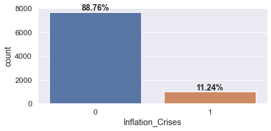

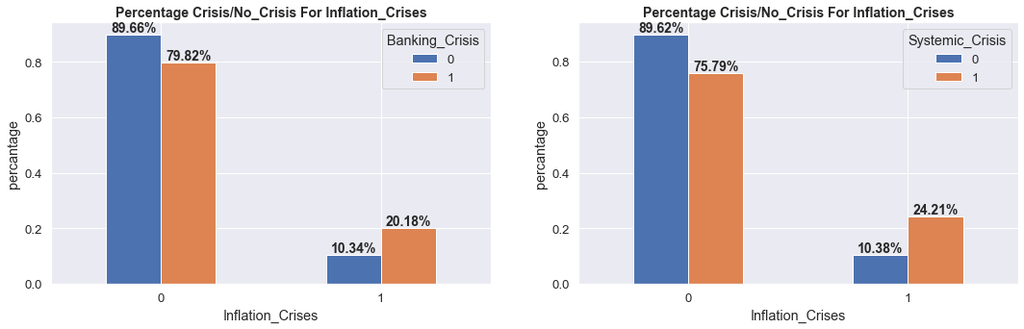

```python
CountPercent(df,"Inflation_Crises")
plt.subplots(figsize=[18,5])
myBarPercent(df,"Inflation_Crises","Banking_Crisis", 1,2,1)
myBarPercent(df,"Inflation_Crises","Systemic_Crisis", 1,2,2)
```

#### `Inflation Crises` affect on `systemic crisis` and `banking crisis` by positive.

## Level_Country

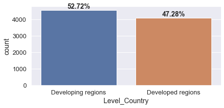

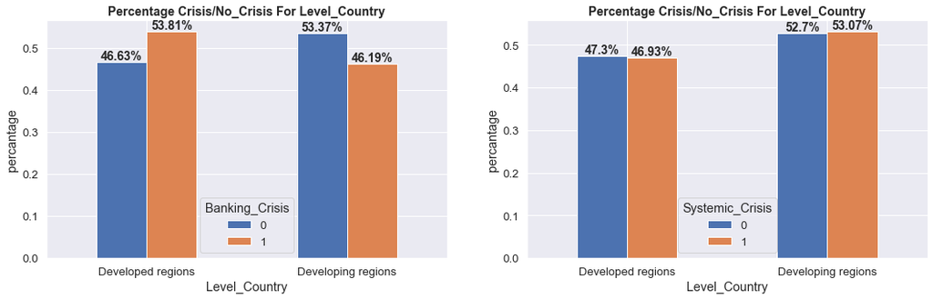

```python
CountPercent(df,"Level_Country")
plt.subplots(figsize=[18,5])
myBarPercent(df,"Level_Country","Banking_Crisis", 1,2,1)
myBarPercent(df,"Level_Country","Systemic_Crisis", 1,2,2)
```

#### `Level Country` affect on `banking crisis` by negative, but not clear with `systemic crisis` .

## Gold_Standard

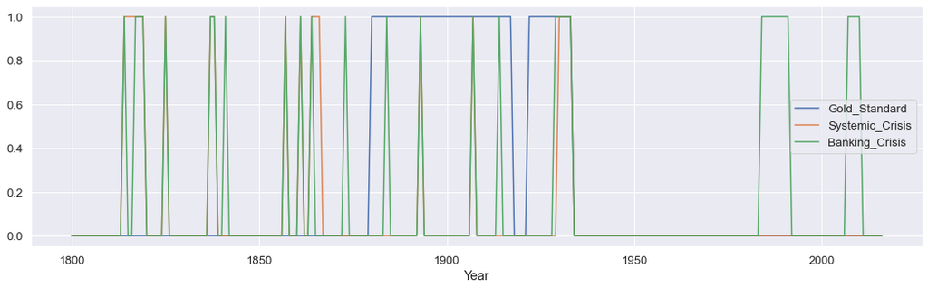

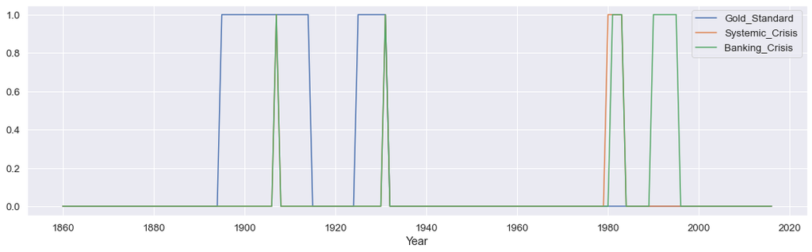

```python
df_us[["Gold_Standard","Systemic_Crisis","Banking_Crisis"]].plot(figsize=(18,5));
df_egypt[["Gold_Standard","Systemic_Crisis","Banking_Crisis"]].plot(figsize=(18,5));
```

#### `Gold Standard` has no clear affect on `systemic crisis` or`banking crisis` clearly.

## Exch_Usd

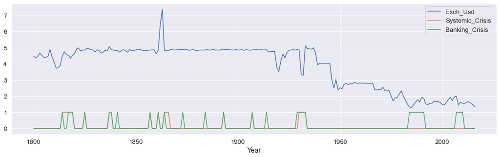

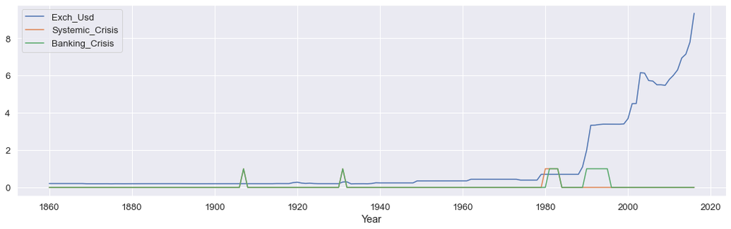

```python
df_us[["Exch_Usd","Systemic_Crisis","Banking_Crisis"]].plot(figsize=(18,5));
df_egypt[["Exch_Usd","Systemic_Crisis","Banking_Crisis"]].plot(figsize=(18,5));
```

## GDP_Weighted_Default

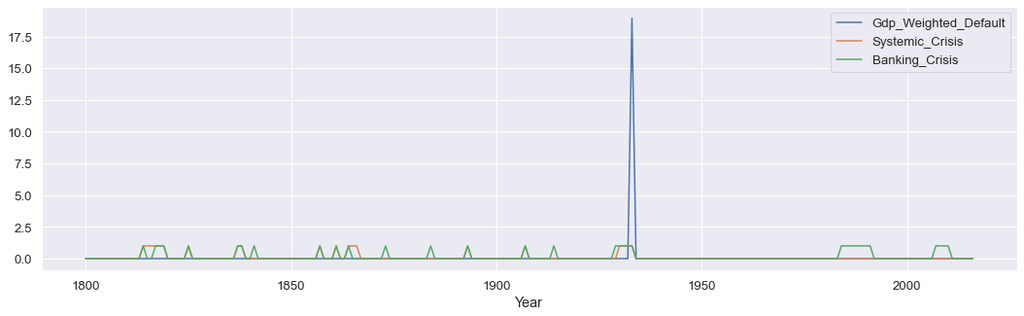

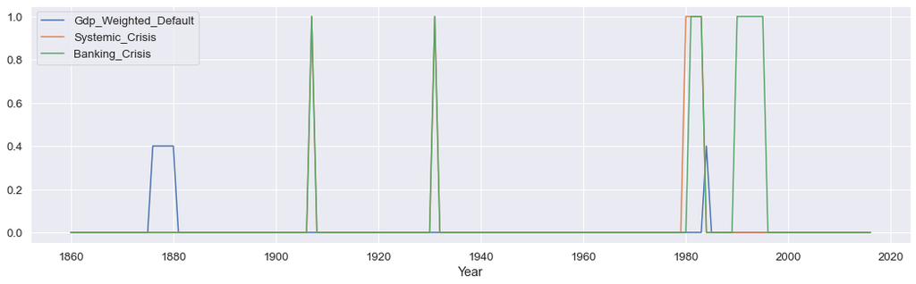

```python
df_us[["Gdp_Weighted_Default","Systemic_Crisis","Banking_Crisis"]].plot(figsize=(18,5));
df_egypt[["Gdp_Weighted_Default","Systemic_Crisis","Banking_Crisis"]].plot(figsize=(18,5));
```

#### Don't relationship clear between `GDP Weighted Default` and `Systemic Crisis` and `Banking Crisis` .

## Inflation

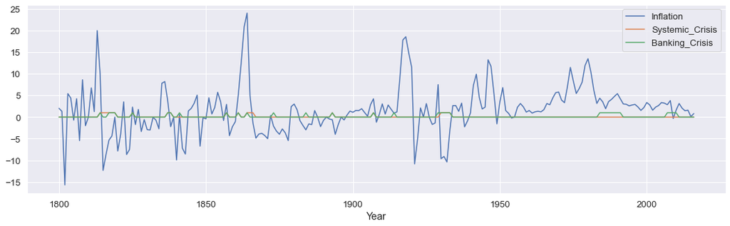

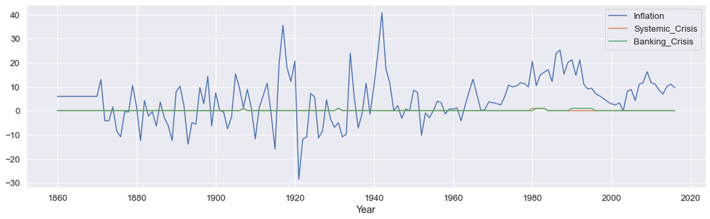

```python
df_us[["Inflation","Systemic_Crisis","Banking_Crisis"]].plot(figsize=(18,5));
df_egypt[["Inflation","Systemic_Crisis","Banking_Crisis"]].plot(figsize=(18,5));
```

#### There a relationship between `Inflation` and `Systemic Crisis` and `Banking_Crisis`.

## Inflation, Inflation_crises, Currency_Crises

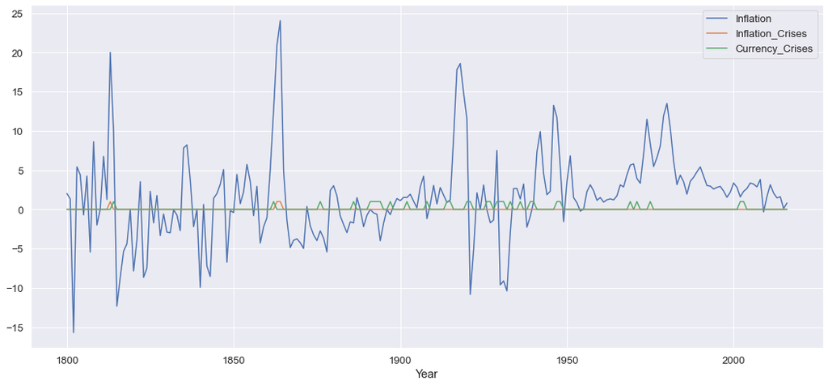

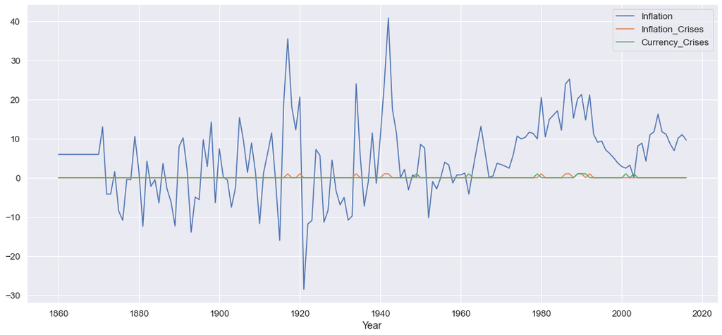

```python
df_us[["Inflation","Inflation_Crises","Currency_Crises"]].plot(figsize=(18,8));
df_egypt[["Inflation","Inflation_Crises","Currency_Crises"]].plot(figsize=(18,8));
```

#### There a relationship between each from `Inflation` and `Inflation crises` and `Currency Crises`.

#### Domestic_Debt_In_Default , Sovereign_External_Debt_1, Sovereign_External_Debt_2, GDP_Weighted_Default

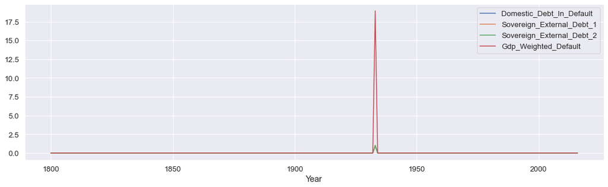

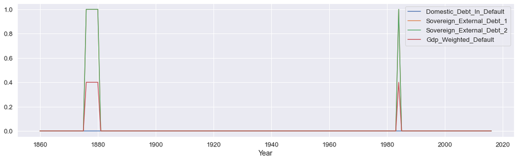

```python
df_us[["Domestic_Debt_In_Default","Sovereign_External_Debt_1","Sovereign_External_Debt_2","Gdp_Weighted_Default"]].plot(figsize=(18,5));
df_egypt[["Domestic_Debt_In_Default","Sovereign_External_Debt_1","Sovereign_External_Debt_2","Gdp_Weighted_Default"]].plot(figsize=(18,5));
```

## Conclusions

### From the information above it becomes clear that:

### (1)

> - the occurrence of `Banking Crisis` Cause in a `Systemic Crisis`, at a rate of `62%`.
> - In contrast, that the occurrence of `Systemic Crisis` It was because a `Banking Crisis`, at a rate of `91%`.
> - The occurrence rate of `Banking Crisis` are higher than `Systemic Crisis` by `47%`.